# Wavelets: extracting sinusoidal factors

Kushal K Dey

December 12, 2015

## Background

In this script, we use the wavelet technique for a sinusoidal time series function and then perform factor analysis using the **PMA** package by Witten and Tibshirani (PMD - penalized matrix decomposition approach).

## Toy example (sinusoidal data matrix)

We simulate the sinusoidal expression for $100$ genes over $256$ time points in order, where the amplitudes for all the genes are $10$, the phases for the first $50$ genes are $2$ and that of the last $50$ genes being $5$. The error variation besides the signal for each genes is taken to be generated from $\chi^2_{4}$ distribution. So, there are two groups of genes depending on gene phases (the first $50$ coming from one phase and the last $50$ from another).

```r
library(PMA)
library(cellcycleR)
library(wavethresh)
G <- 100;
num_cells <- 256;
amp_genes1 <- rep(10, G);
phi_genes1 <- rep(c(2,5), each=G/2);
sigma_genes1 <- rchisq(G, 4);
cell_times_sim <- sort(sample(seq(0,2*pi, 2*pi/(num_cells-1)), num_cells, replace=FALSE));
cycle_data <- t(sim_sinusoidal_cycle(G, amp_genes1, phi_genes1, sigma_genes1, cell_times_sim));
```

The sinusoidal patterns for two cases from the two groups of gene phases given as follows. Ideally these are how the two factors in a factor analysis model on this data would look like.

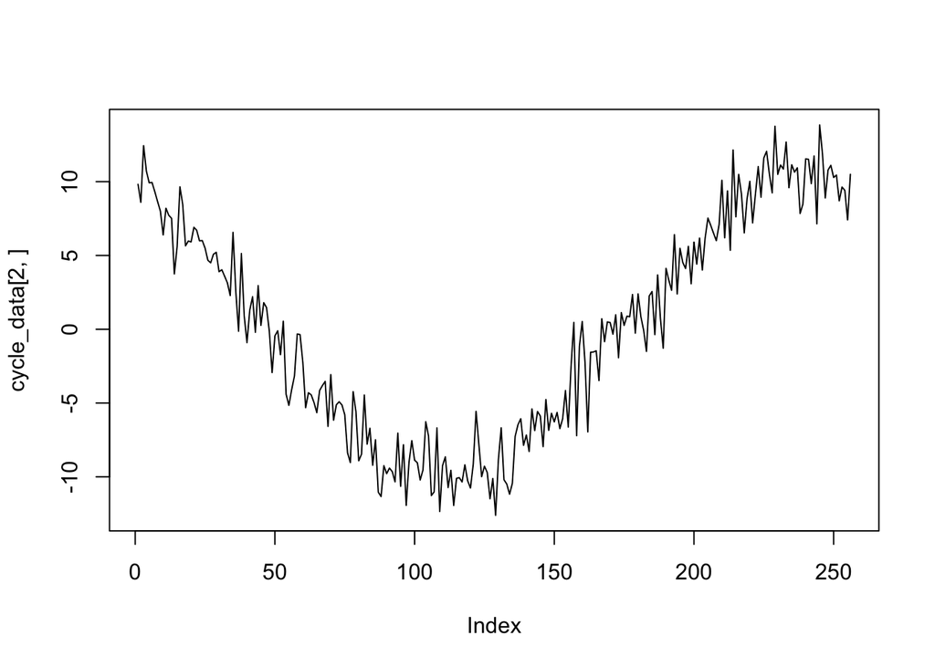

```r
plot(cycle_data[2,], type="l");
```

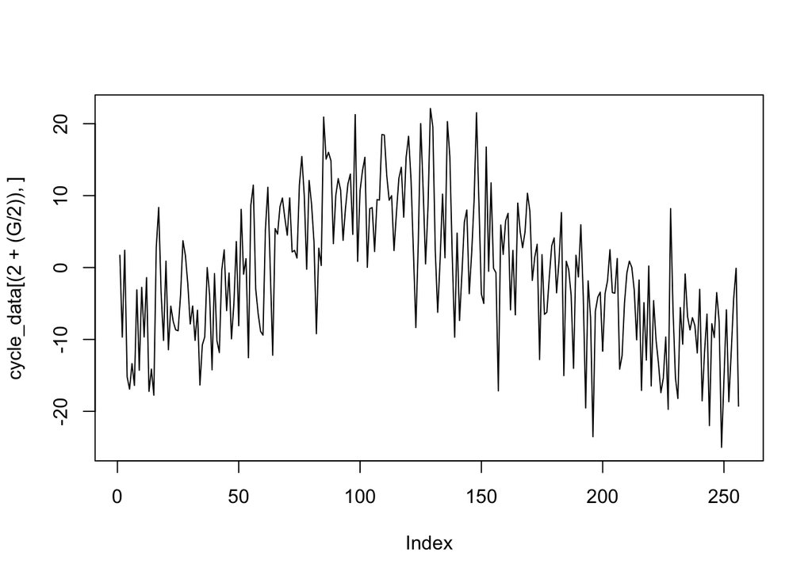

```r
plot(cycle_data[(2+(G/2)),], type="l")
```

## Applying PMD on data matrix

Next we apply the decomposition of the data matrix using the *PMD()* function of the **PMA** package.

```r
pmd1 <- PMD(cycle_data, type="standard", K=2, niter=50);
```

```
## 1234567891011121314151617181920212223242526272829303132333435363738394041424344454647484950
## 123456789101112131415
```

We then present the barplots of the $u$ and $v$ matrices obtained from fitting the penalized matrix decomposition.

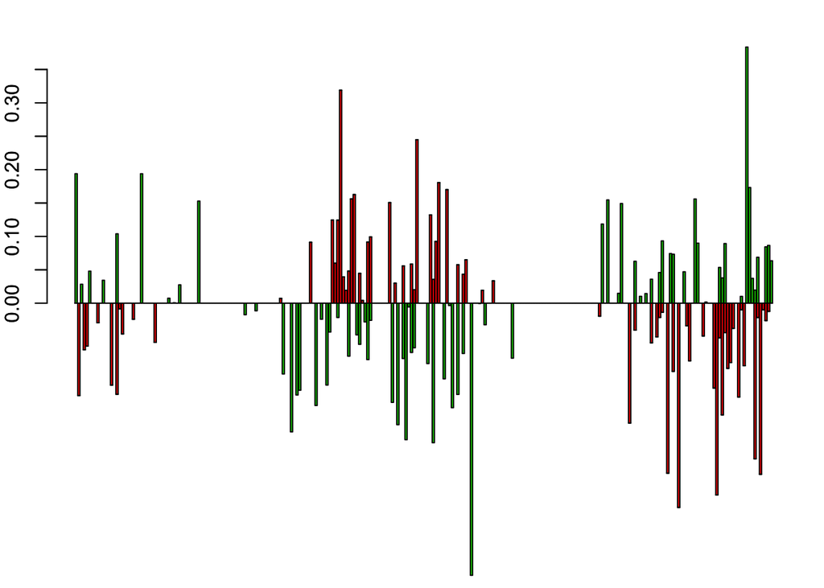

```r
pos1<- apply(pmd1$v, c(1,2), function(x) return (max(x,0)))
neg1 <- apply(pmd1$v, c(1,2), function(x) return (min(x,0)))

par(mar=c(12,2,2,1))
barplot(t(pos1), col=2:3)
barplot(t(neg1), col=2:3, add=TRUE)
```

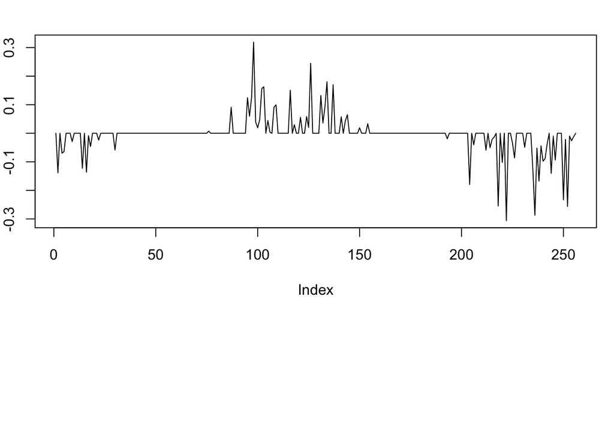

```r
plot(pmd1$v[,1], type="l")
```

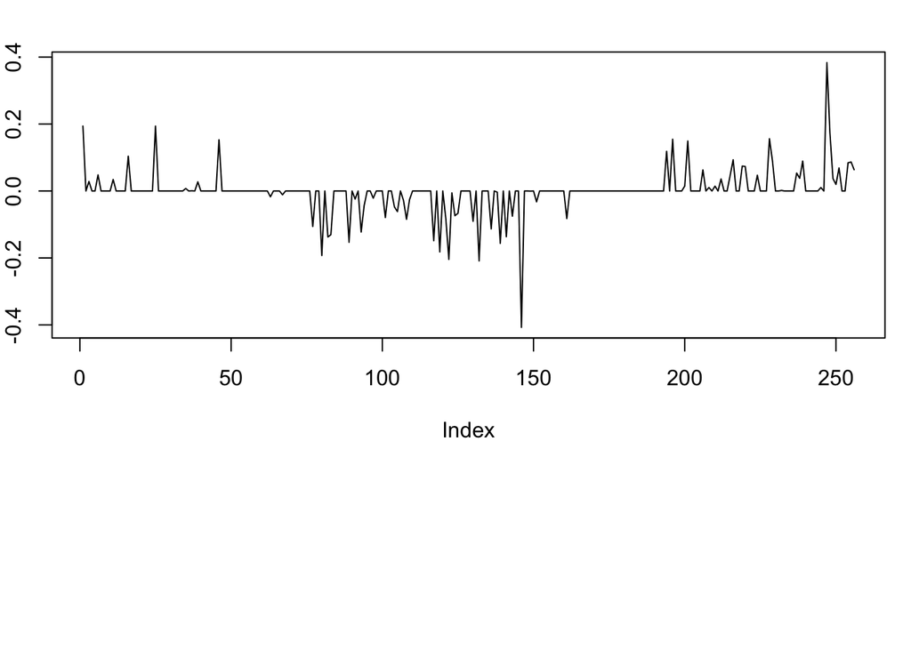

```r
plot(pmd1$v[,2], type="l")
```

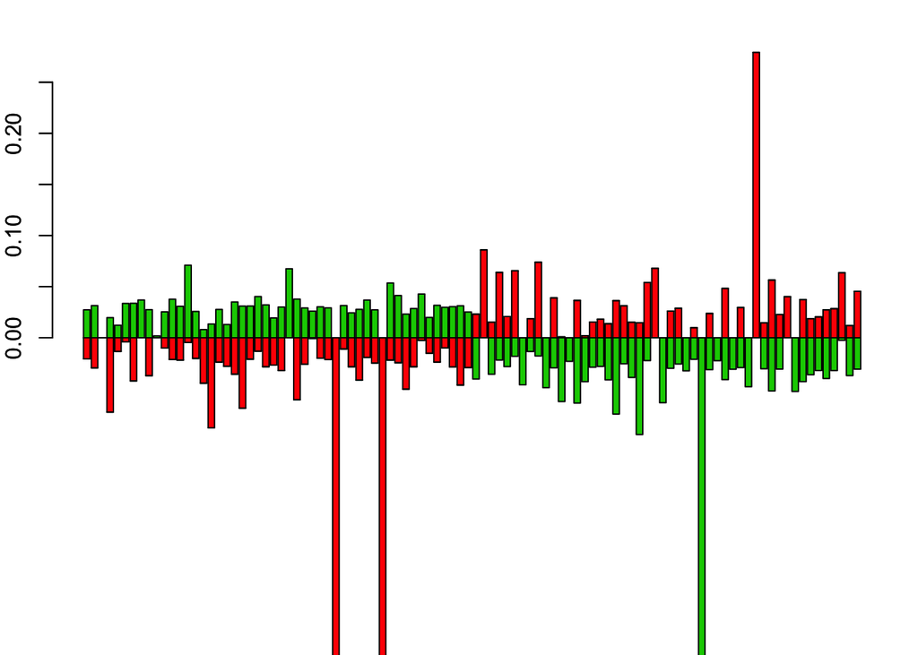

```r
pos2 <- apply(pmd1$u, c(1,2), function(x) return (max(x,0)))
neg2 <- apply(pmd1$u, c(1,2), function(x) return (min(x,0)))

par(mar=c(12,2,2,1))
barplot(t(pos2), col=2:3)
barplot(t(neg2), col=2:3, add=TRUE)
```

## Wavelet transform of sinusoidal data matrix

We now first apply wavelet transform on the genes (rows) for the data matrix.

```r
wave_data <- t(apply(cycle_data, 1, function(x)
                                  {
                                      out <- wd(x, filter.number = 3, family = "DaubExPhase")
                                      return(out$D)
                                  }));
```

## Applying PMD on wavelet transformed data

Now apply the decomposition of this wavelet transformed data matrix using the *PMD()* function of **PMA** package.

```r
pmd2 <- PMD(wave_data, type="standard", K=2, niter=50);
```

```
## 1234567891011121314151617181920212223242526272829
## 123456789101112131415161718192021222324252627282930
```

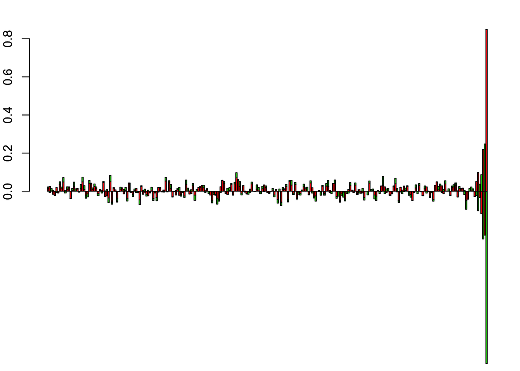

```r
pos1<- apply(pmd2$v, c(1,2), function(x) return (max(x,0)))
neg1 <- apply(pmd2$v, c(1,2), function(x) return (min(x,0)))

par(mar=c(12,2,2,1))
barplot(t(pos1), col=2:3)
barplot(t(neg1), col=2:3, add=TRUE)
```

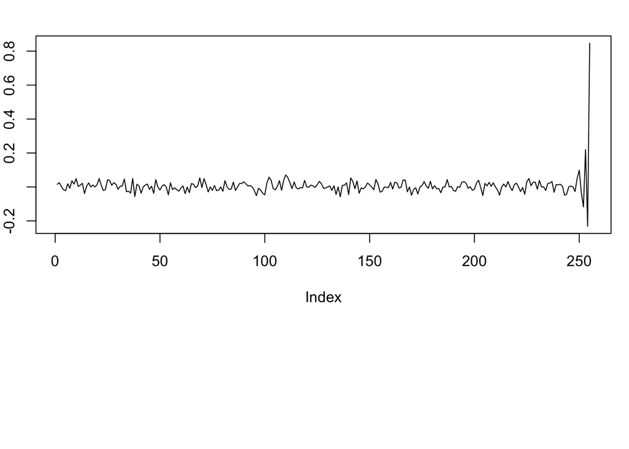

```r
plot(pmd2$v[,1], type="l")
```

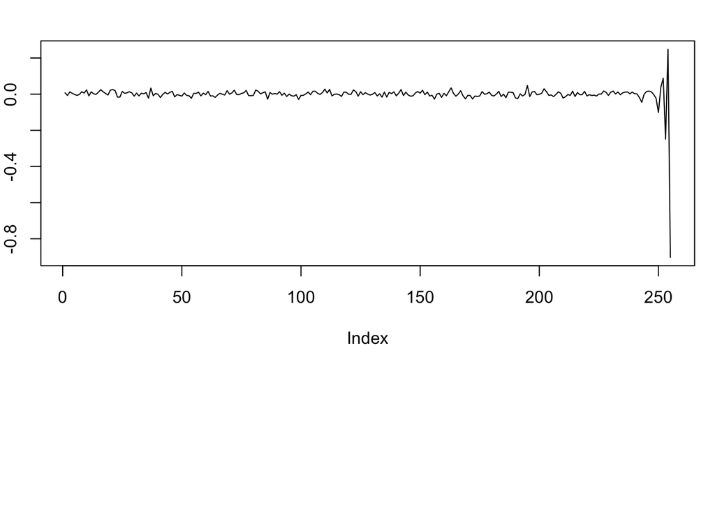

```r
plot(pmd2$v[,2], type="l")
```

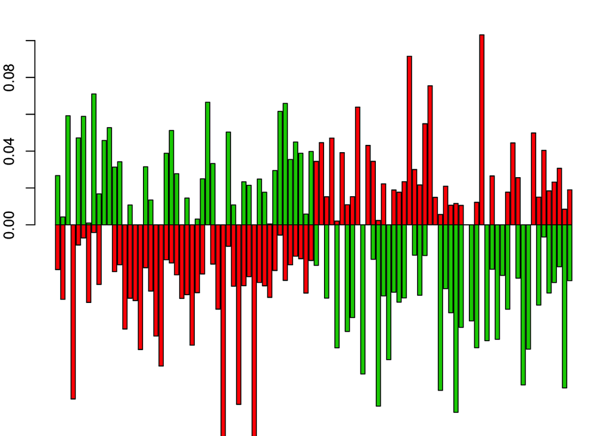

```r
pos2 <- apply(pmd2$u, c(1,2), function(x) return (max(x,0)))
neg2 <- apply(pmd2$u, c(1,2), function(x) return (min(x,0)))

par(mar=c(12,2,2,1))
barplot(t(pos2), col=2:3)
barplot(t(neg2), col=2:3, add=TRUE)
```

## Recreating back factors from wavelet transform

We now recreate the factors in the actual space by reverse transforming the factors produced from applying sparse factor analysis on the wavelet transformed data matrix.

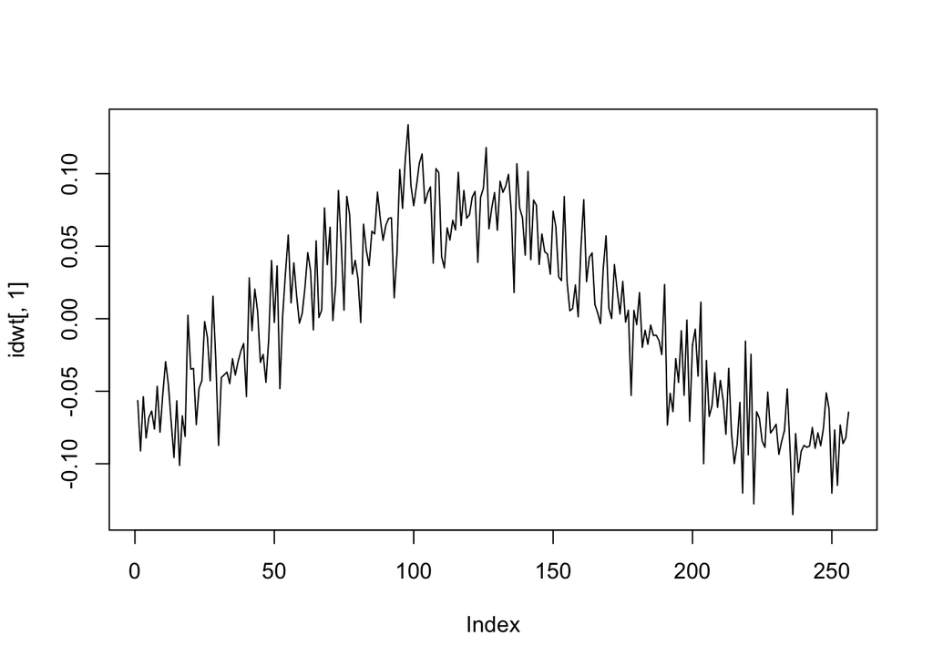

```r
W <- GenW(n=num_cells, filter.number=3, family="DaubExPhase")
idwt <- W[,-1] %*% pmd2$v;
plot(idwt[,1], type="l")
```

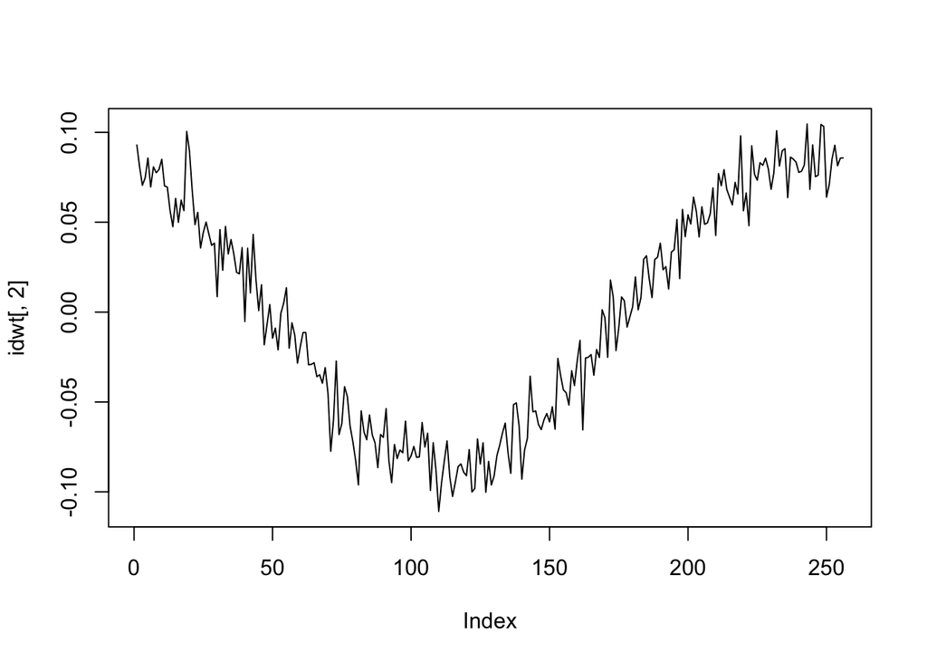

```r
plot(idwt[,2], type="l")
```

## Conclusion

The factor analysis on wavelet transformed data does a much better job at recreating the original factor sinusoidal patterns, compared to the factor analysis model without wavelet transform.